# wildfires

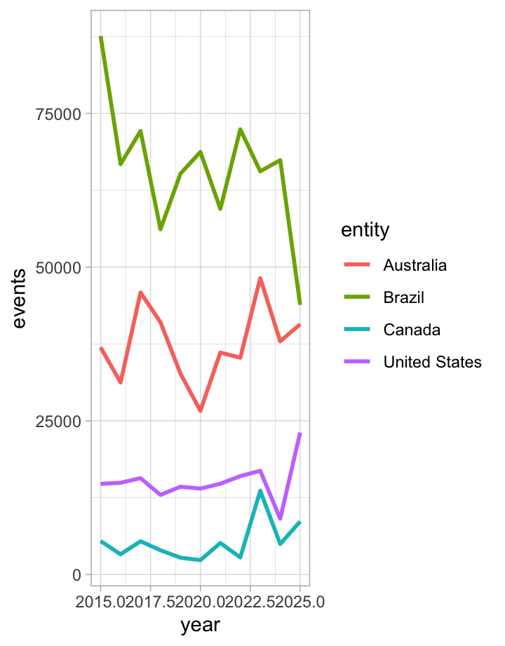

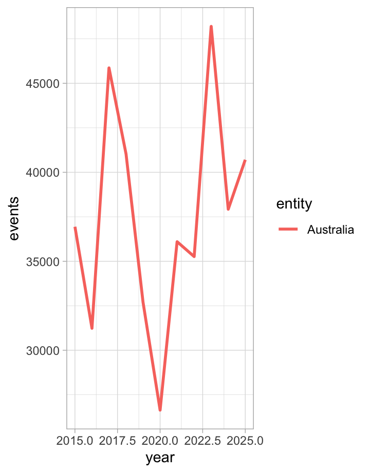

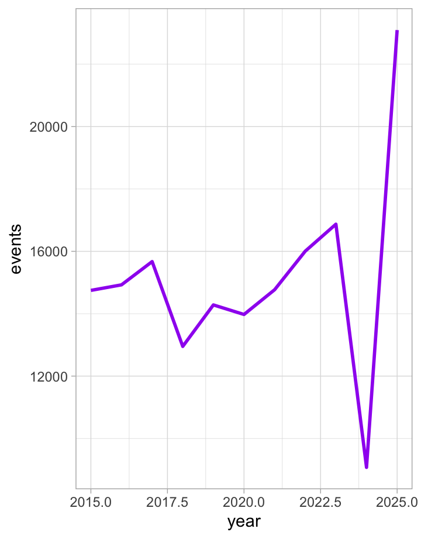

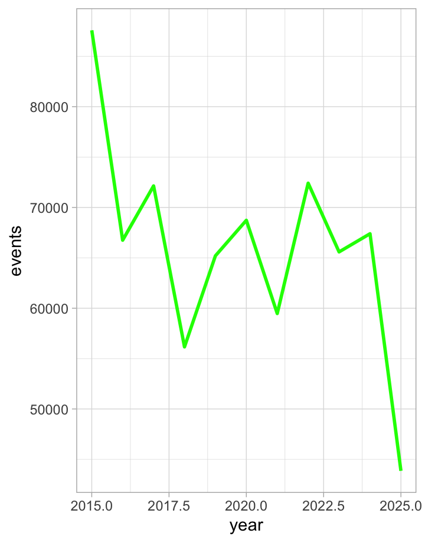

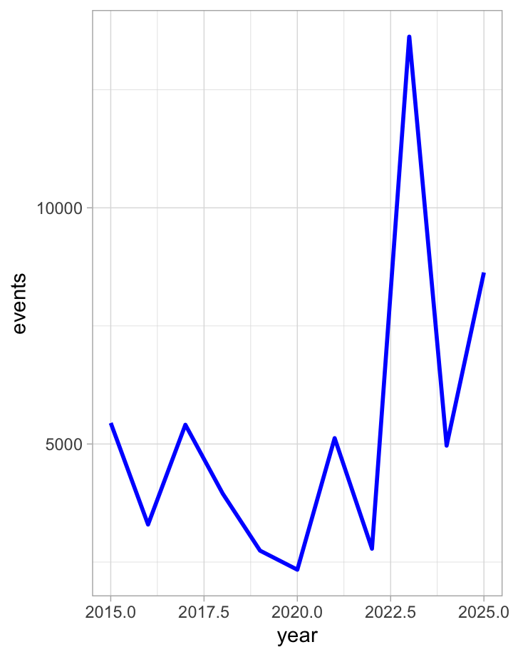

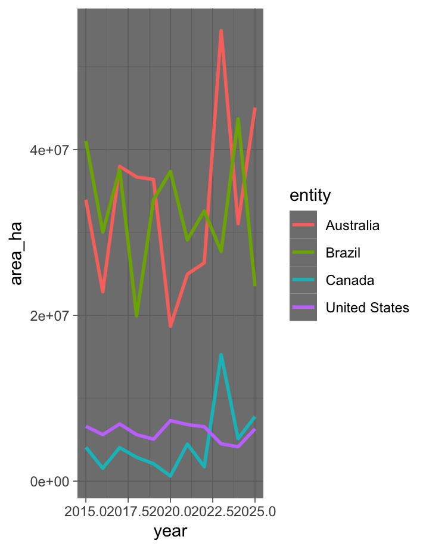

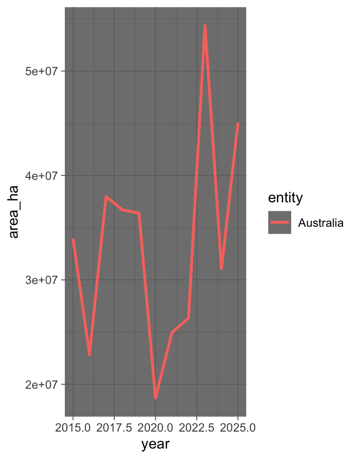

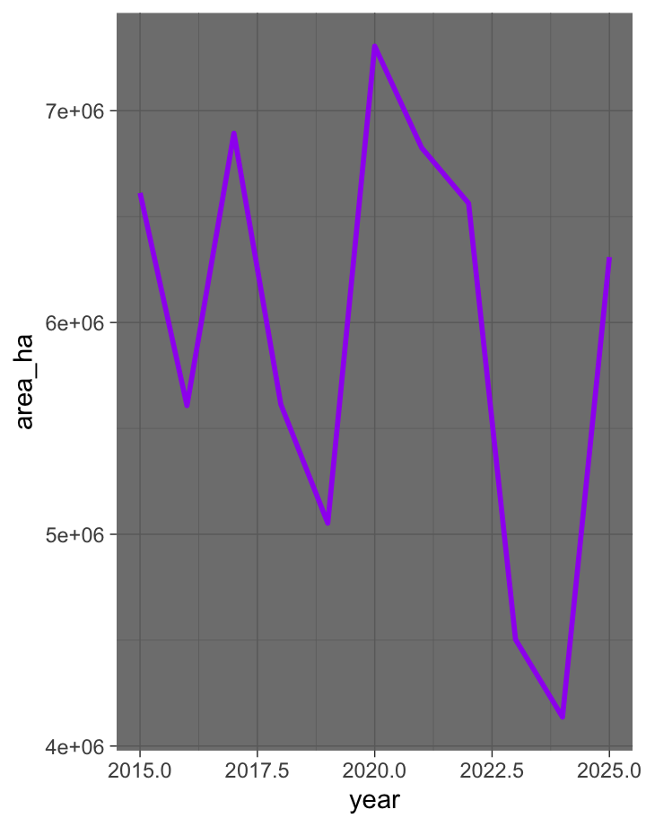

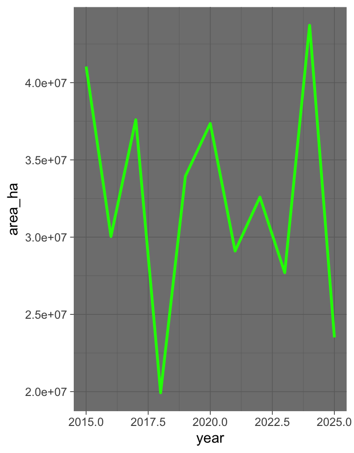

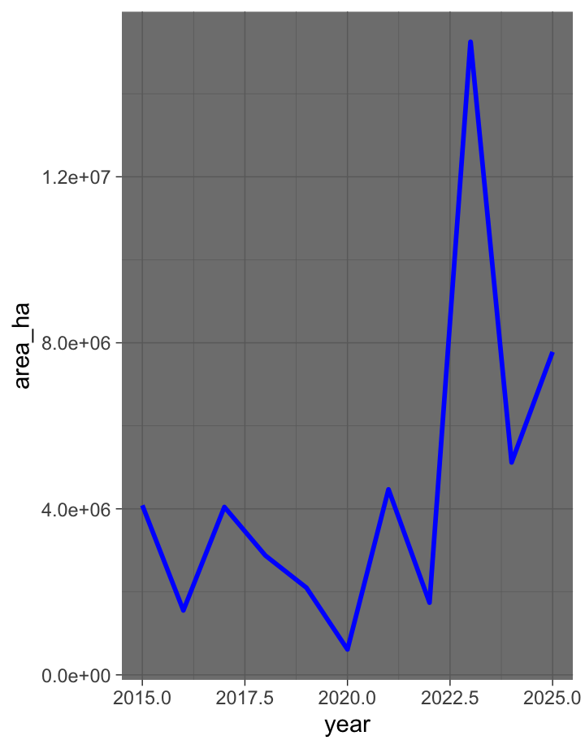

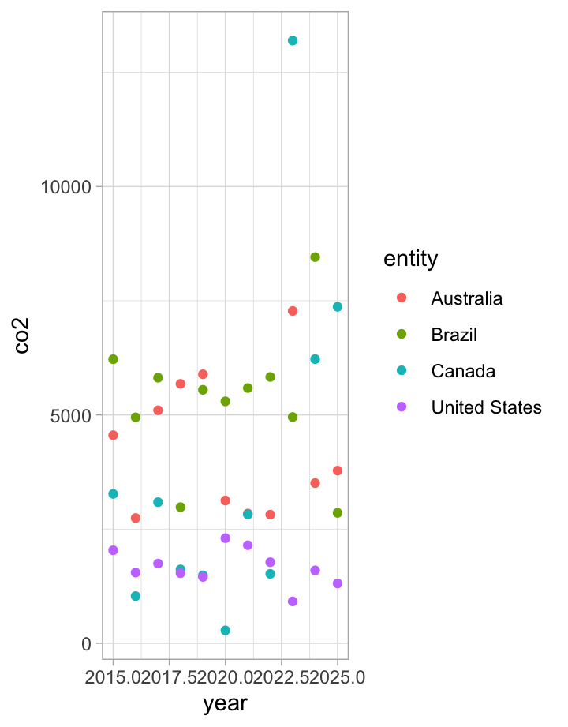

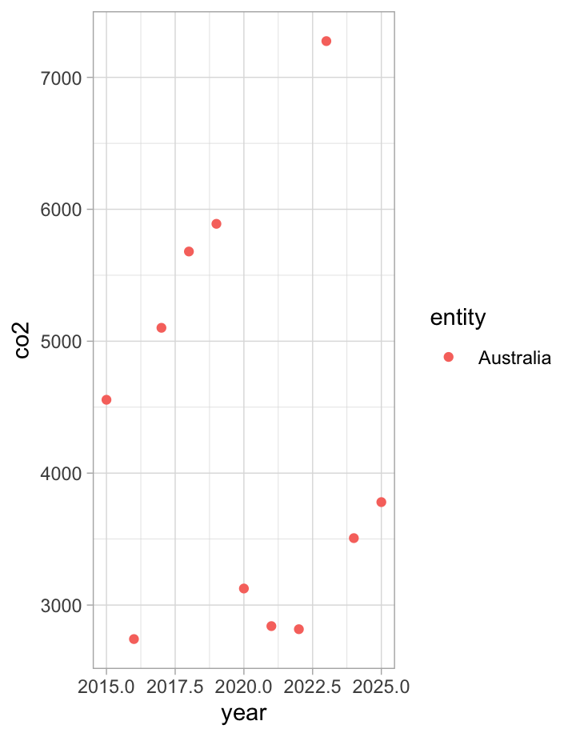

[3 more figures not shown]

# Annual number of wildfires

### Wildfires

| entity | code | year | events |
| --- | --- | --- | --- |
| Australia | AUS | 2015 | 36940 |
| Australia | AUS | 2016 | 31234 |
| Australia | AUS | 2017 | 45867 |
| Australia | AUS | 2018 | 41031 |
| Australia | AUS | 2019 | 32681 |
| Australia | AUS | 2020 | 26634 |
| Australia | AUS | 2021 | 36099 |
| Australia | AUS | 2022 | 35263 |
| Australia | AUS | 2023 | 48199 |
| Australia | AUS | 2024 | 37923 |
| Australia | AUS | 2025 | 40704 |
| Brazil | BRA | 2015 | 87580 |
| Brazil | BRA | 2016 | 66747 |
| Brazil | BRA | 2017 | 72135 |
| Brazil | BRA | 2018 | 56158 |
| Brazil | BRA | 2019 | 65199 |
| Brazil | BRA | 2020 | 68723 |
| Brazil | BRA | 2021 | 59470 |
| Brazil | BRA | 2022 | 72406 |
| Brazil | BRA | 2023 | 65585 |
| Brazil | BRA | 2024 | 67389 |
| Brazil | BRA | 2025 | 43858 |
| Canada | CAN | 2015 | 5445 |
| Canada | CAN | 2016 | 3295 |
| Canada | CAN | 2017 | 5407 |
| Canada | CAN | 2018 | 3951 |
| Canada | CAN | 2019 | 2743 |
| Canada | CAN | 2020 | 2339 |
| Canada | CAN | 2021 | 5124 |
| Canada | CAN | 2022 | 2783 |
| Canada | CAN | 2023 | 13624 |
| Canada | CAN | 2024 | 4965 |
| Canada | CAN | 2025 | 8631 |
| United States | USA | 2015 | 14748 |
| United States | USA | 2016 | 14926 |
| United States | USA | 2017 | 15671 |
| United States | USA | 2018 | 12952 |
| United States | USA | 2019 | 14282 |
| United States | USA | 2020 | 13976 |
| United States | USA | 2021 | 14770 |
| United States | USA | 2022 | 16006 |
| United States | USA | 2023 | 16870 |
| United States | USA | 2024 | 9073 |
| United States | USA | 2025 | 23095 |

### Wildfires

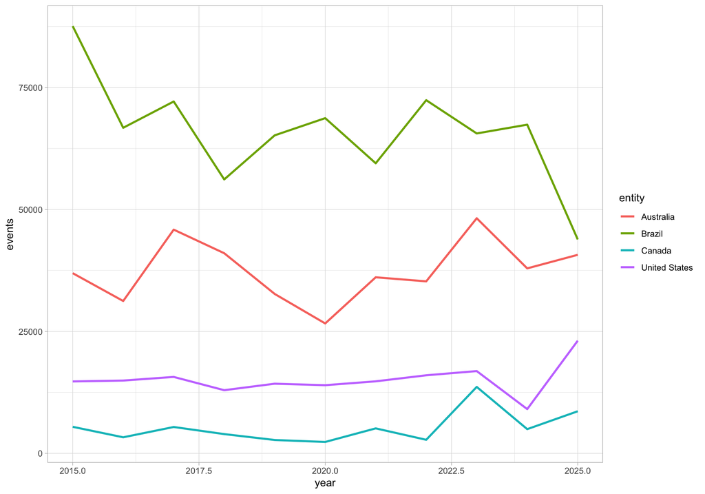

### Australia

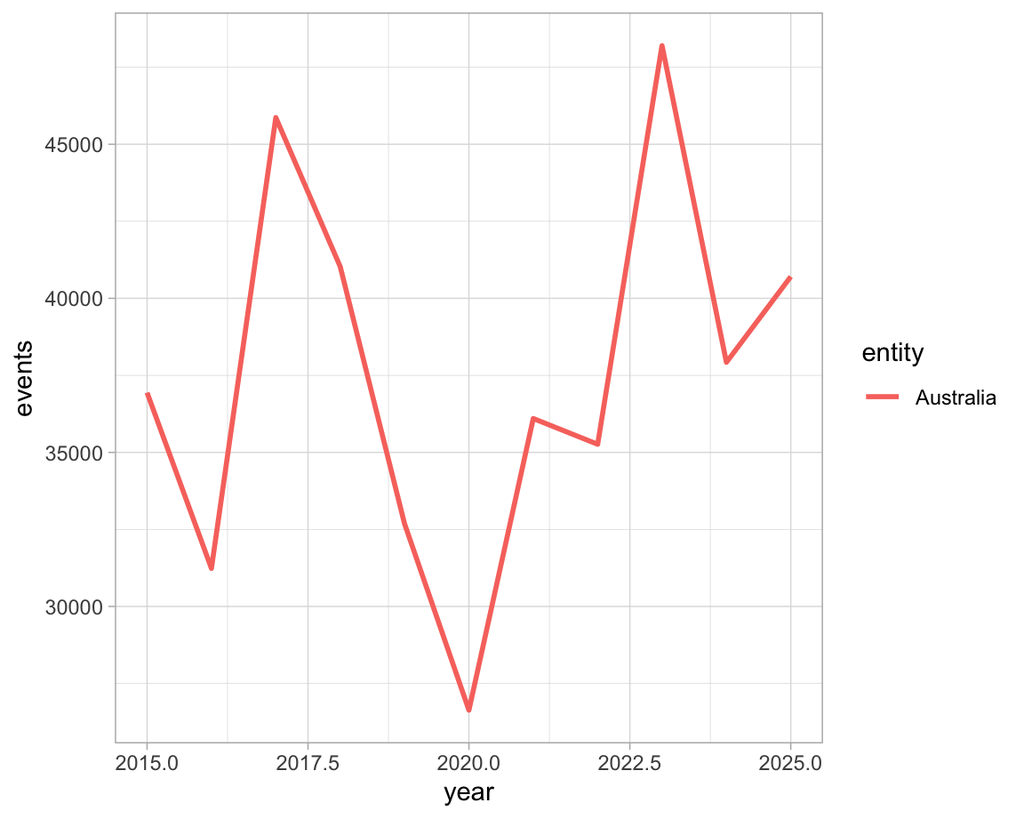

### United States

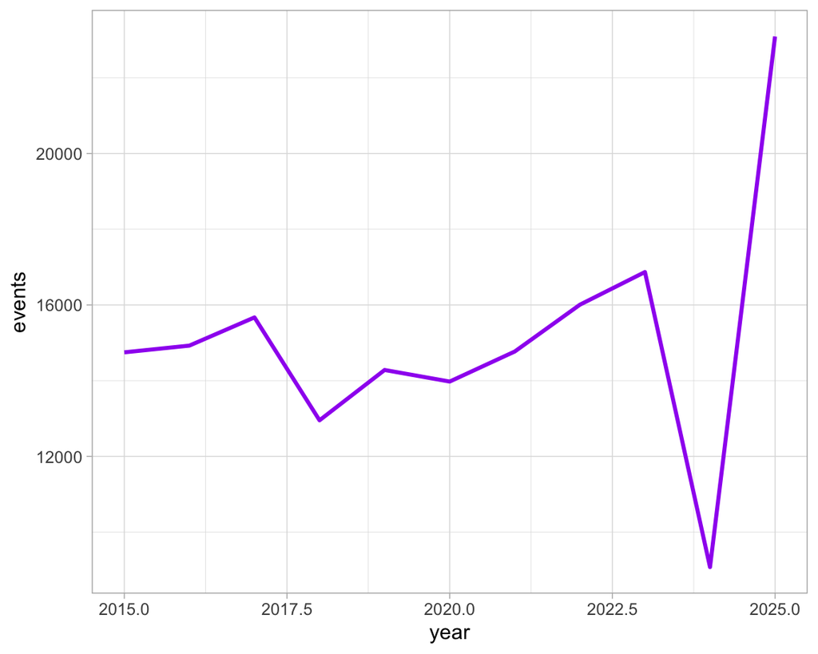

### Brazil

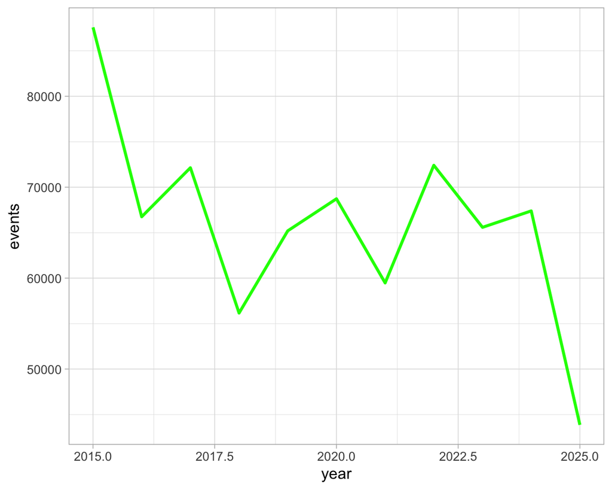

### Canada

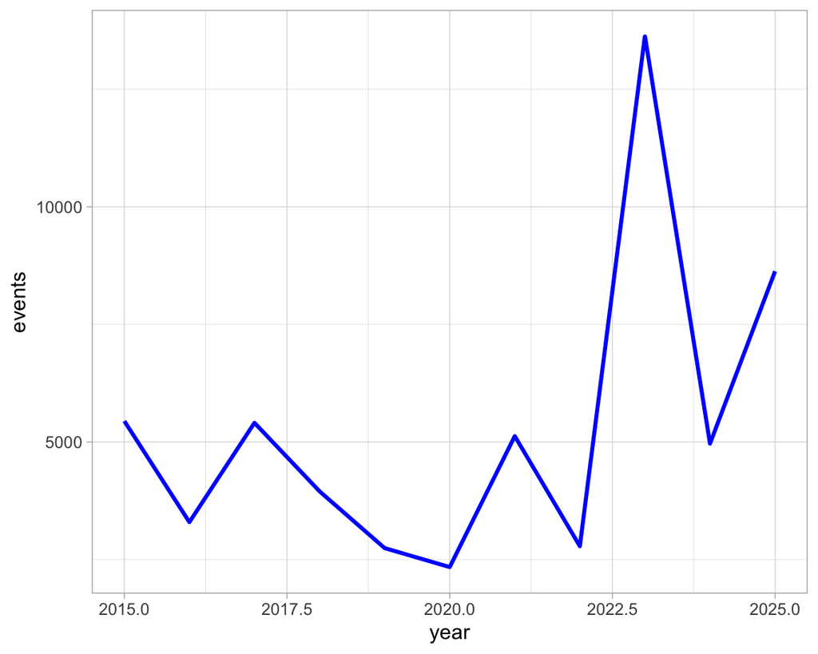

### SDG: Life on Land and Climate Action

What is Canada doing to prevent wildfires? Canada has created the pan-Canadian Wild land Fire Prevention and Mitigation group. The goals of of this group is to educate the public, to enhance collaboration of the public, strengthen partnerships, and expand investments in prevention methods. These methods include fighting fire with fire. This means using prescribed fires to clear up built up fuel in the forests. Burning this reduces the chances of a devastating fire.

What is a Australia doing to prevent wildfires? Fires have been a part of Australia’s history for hundreds of years. Over the years these fires have become increasingly more dangerous. When is comes to spreading the fires, the government of Australia is beginning to implement fire resistant buildings in areas where fire danger is high. This will hopefully help with the spread of wildfires and their intensity.

What is the United States doing to prevent wildfires? Similarly to Canada they are using the method of fighting fire with fire. Like in Sewanee, with our prescribed fire team, the forest service is doing controlled burns in specific areas with the goal of preventing the spread of wildfires. These controlled burns are used to limit the amount of built up fuel in that forest. This type of burning can also be used for restoration purposes.

# Annual area burned by wildfires

### Area burned

| entity | code | year | area_ha |
| --- | --- | --- | --- |
| Australia | AUS | 2015 | 33967664 |
| Australia | AUS | 2016 | 22835256 |
| Australia | AUS | 2017 | 37974830 |
| Australia | AUS | 2018 | 36700170 |
| Australia | AUS | 2019 | 36397800 |
| Australia | AUS | 2020 | 18683630 |
| Australia | AUS | 2021 | 24958528 |
| Australia | AUS | 2022 | 26340776 |
| Australia | AUS | 2023 | 54354840 |
| Australia | AUS | 2024 | 31066002 |
| Australia | AUS | 2025 | 45067704 |
| Brazil | BRA | 2015 | 41041716 |
| Brazil | BRA | 2016 | 30046108 |
| Brazil | BRA | 2017 | 37599004 |
| Brazil | BRA | 2018 | 19926660 |
| Brazil | BRA | 2019 | 33956044 |
| Brazil | BRA | 2020 | 37356150 |
| Brazil | BRA | 2021 | 29101620 |
| Brazil | BRA | 2022 | 32589640 |
| Brazil | BRA | 2023 | 27701730 |
| Brazil | BRA | 2024 | 43714092 |
| Brazil | BRA | 2025 | 23509680 |
| Canada | CAN | 2015 | 4085320 |
| Canada | CAN | 2016 | 1552176 |
| Canada | CAN | 2017 | 4044314 |
| Canada | CAN | 2018 | 2874870 |
| Canada | CAN | 2019 | 2099705 |
| Canada | CAN | 2020 | 611974 |
| Canada | CAN | 2021 | 4469059 |
| Canada | CAN | 2022 | 1739592 |
| Canada | CAN | 2023 | 15252934 |
| Canada | CAN | 2024 | 5117483 |
| Canada | CAN | 2025 | 7780717 |
| United States | USA | 2015 | 6611853 |
| United States | USA | 2016 | 5607746 |
| United States | USA | 2017 | 6893415 |
| United States | USA | 2018 | 5613224 |
| United States | USA | 2019 | 5052271 |
| United States | USA | 2020 | 7305050 |
| United States | USA | 2021 | 6825104 |
| United States | USA | 2022 | 6562804 |
| United States | USA | 2023 | 4503223 |
| United States | USA | 2024 | 4136739 |
| United States | USA | 2025 | 6309188 |

### Area burned

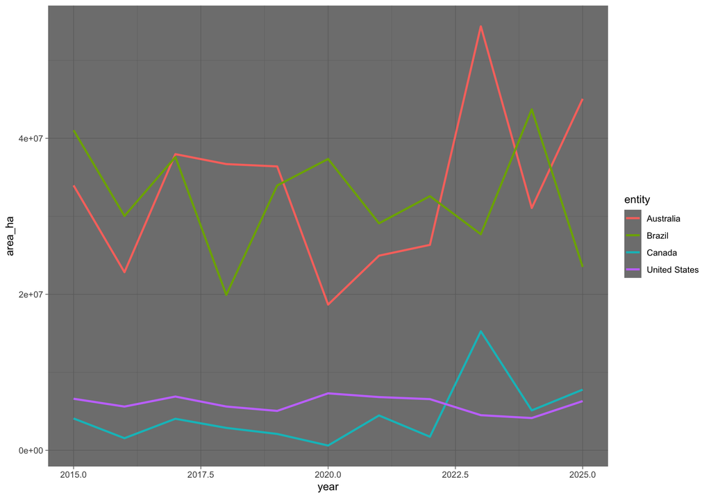

### Australia

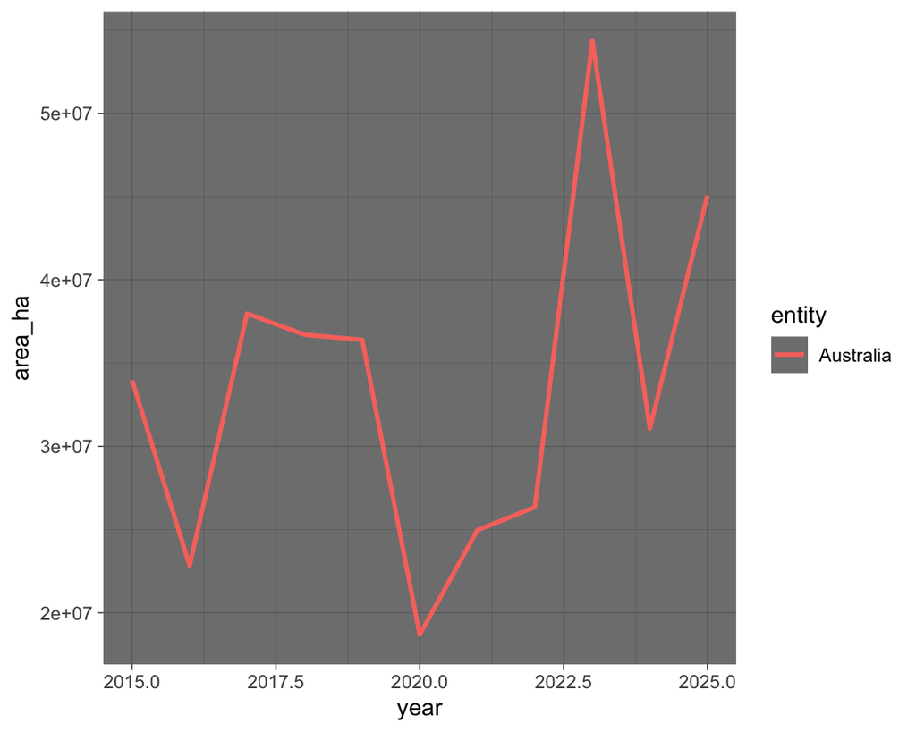

### United States

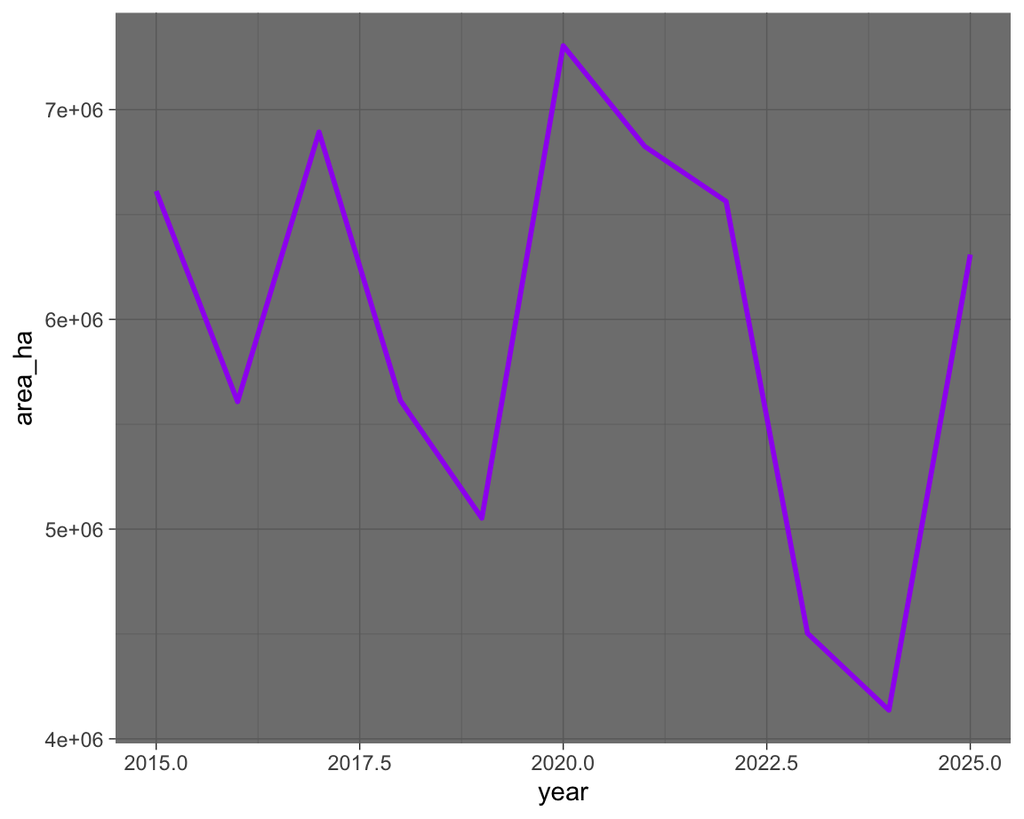

### Brazil

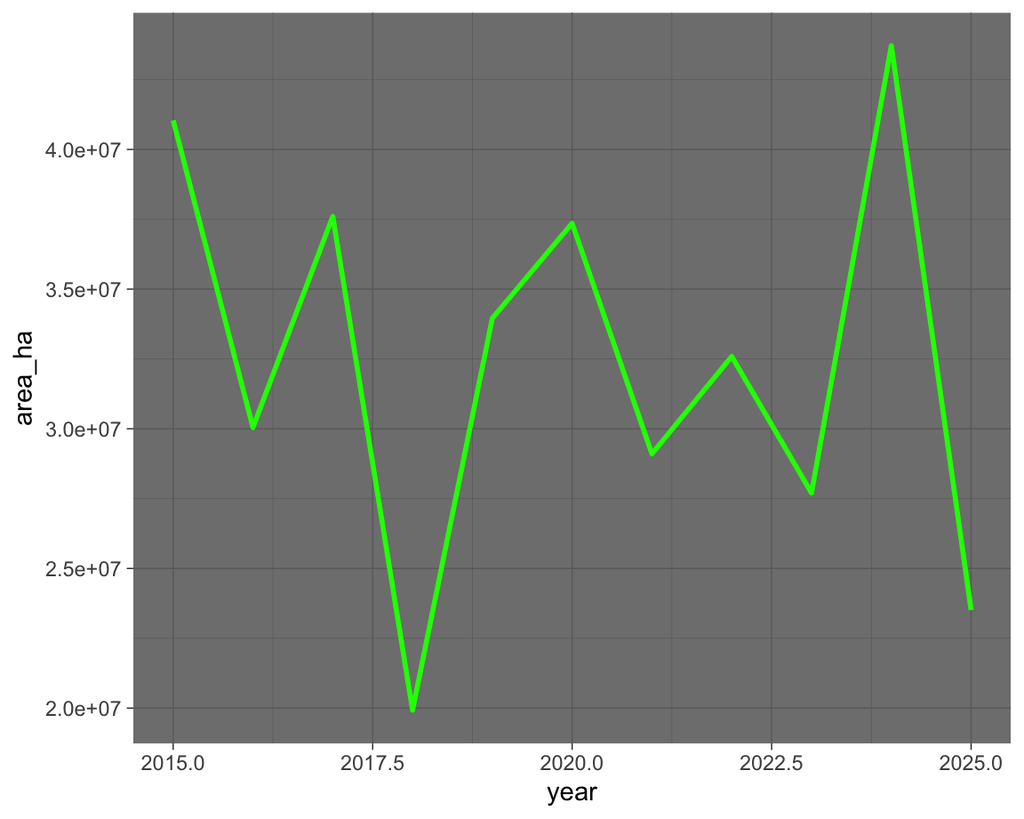

### Canada

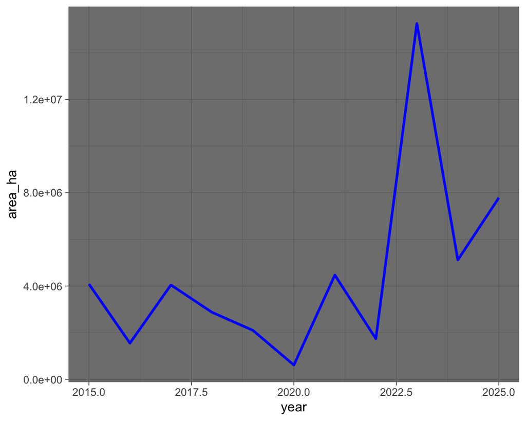

### SDG: Life on Land and Climate Action

Australia

Based on the graphs Australia reaches the most amount of hectares burned. Australia is a very hot country and has a long season of dry and hot weather. These are the perfect conditions for a very hot and fast moving wildfire. Australia specifically experiences bush fires. These are low to the ground fast moving fires. What is very scary about these types of fires is that they can burn just off of the oxygen provided by the soil. Burning this soil so intensely makes the soil infertile this then takes away farm land and any food or habitat for wildlife. Not only does it make the soil infertile but without any vegetation holding the soil down, this increases the erosion risk.

# CO2 Emmisions

### CO2 emissions

| entity | code | year | co2 |
| --- | --- | --- | --- |
| Australia | AUS | 2015 | 455607420 |
| Australia | AUS | 2016 | 274228350 |
| Australia | AUS | 2017 | 510154080 |
| Australia | AUS | 2018 | 567993500 |
| Australia | AUS | 2019 | 588973200 |
| Australia | AUS | 2020 | 312553280 |
| Australia | AUS | 2021 | 284046240 |
| Australia | AUS | 2022 | 281703300 |
| Australia | AUS | 2023 | 727470850 |
| Australia | AUS | 2024 | 350742460 |
| Australia | AUS | 2025 | 378042050 |
| Brazil | BRA | 2015 | 621976060 |
| Brazil | BRA | 2016 | 494710100 |
| Brazil | BRA | 2017 | 581342700 |
| Brazil | BRA | 2018 | 298088200 |
| Brazil | BRA | 2019 | 554918340 |
| Brazil | BRA | 2020 | 529688000 |
| Brazil | BRA | 2021 | 558781400 |
| Brazil | BRA | 2022 | 583065800 |
| Brazil | BRA | 2023 | 495359900 |
| Brazil | BRA | 2024 | 845412800 |
| Brazil | BRA | 2025 | 285520900 |
| Canada | CAN | 2015 | 327092500 |
| Canada | CAN | 2016 | 103389800 |
| Canada | CAN | 2017 | 308962750 |
| Canada | CAN | 2018 | 161809440 |
| Canada | CAN | 2019 | 148870460 |
| Canada | CAN | 2020 | 28272590 |
| Canada | CAN | 2021 | 282139200 |
| Canada | CAN | 2022 | 152049660 |
| Canada | CAN | 2023 | 1319571000 |
| Canada | CAN | 2024 | 622209600 |
| Canada | CAN | 2025 | 736669060 |
| United States | USA | 2015 | 203674660 |
| United States | USA | 2016 | 154846320 |
| United States | USA | 2017 | 174504530 |
| United States | USA | 2018 | 153534430 |
| United States | USA | 2019 | 145369300 |
| United States | USA | 2020 | 230280060 |
| United States | USA | 2021 | 214744300 |
| United States | USA | 2022 | 177575100 |
| United States | USA | 2023 | 91641736 |
| United States | USA | 2024 | 159623200 |
| United States | USA | 2025 | 131072270 |

### Carbon Emissions

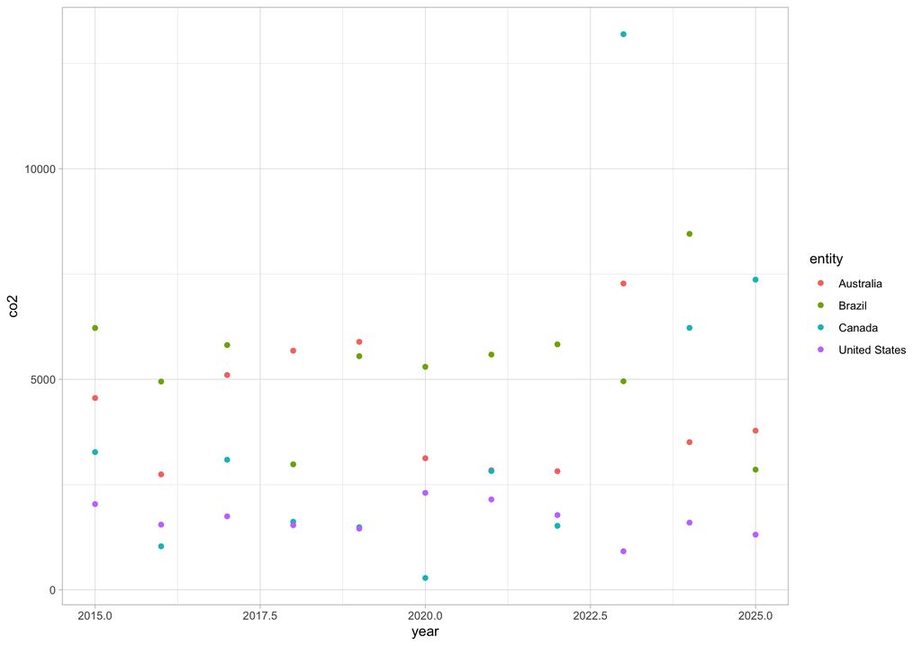

### Australia

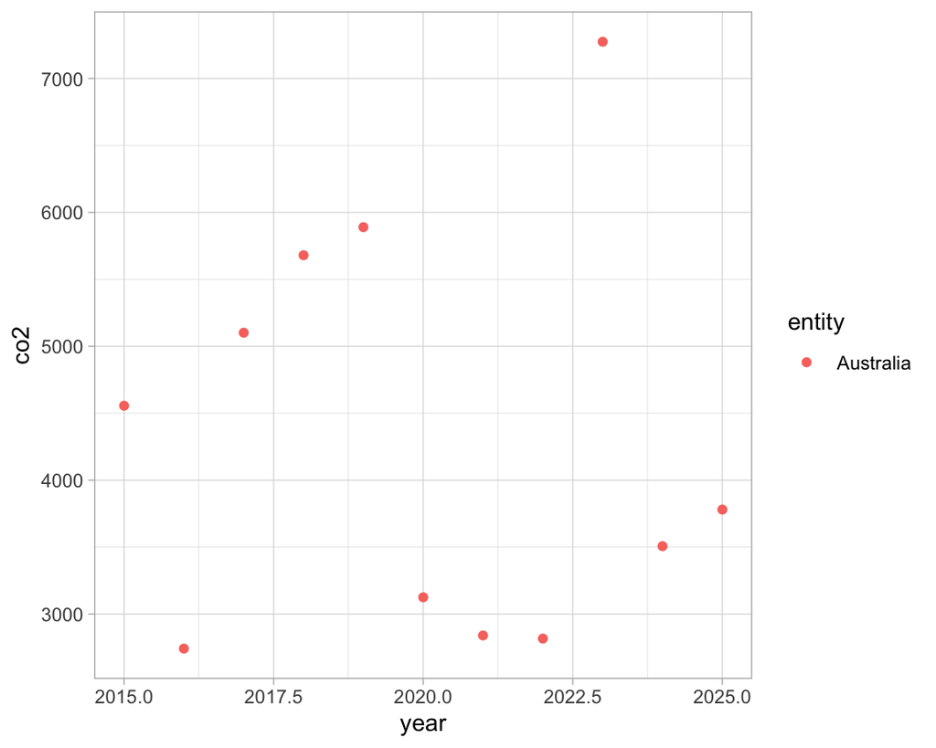

### United States

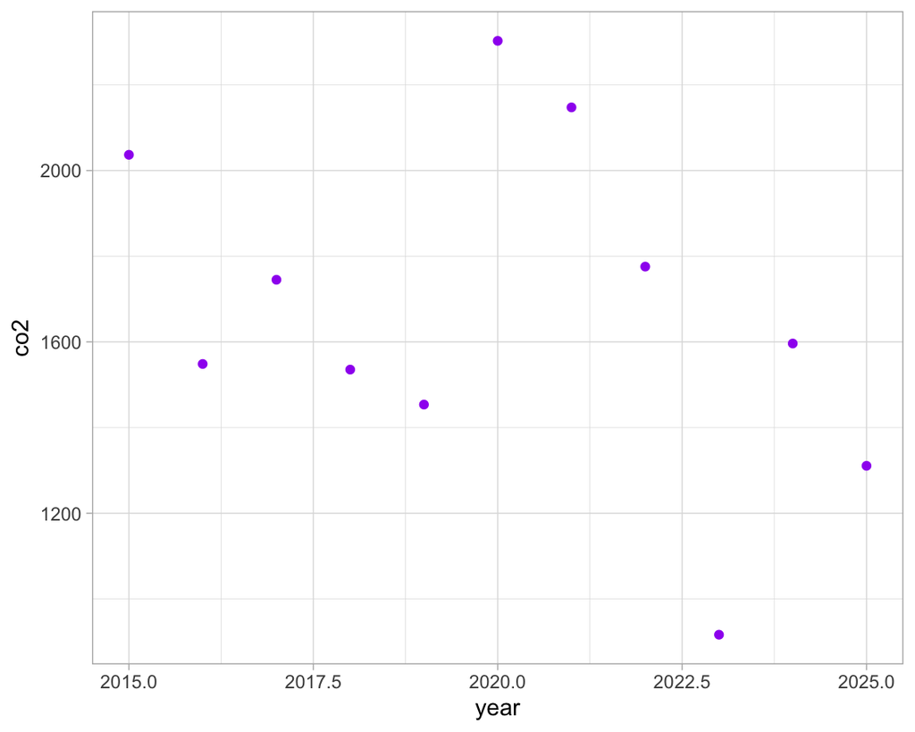

### Brazil

[figure not shown]

### Canada

[figure not shown]

### SDG: Life on Land and Climate Action

Wildfires and climate change

Wildfires are becoming the “new normal”. In all of these countries they are trying different strategies to help prevent wildfires from becoming our “new normal”. With wildfires becoming so common, this increases the CO2 emissions. CO2 emissions are so important when talking about climate change because, this gas is acting as a blanket in the atmosphere and keeping all of the other harmful emissions in the lowest level of the atmosphere that we breath in. With the increase in greenhouse gasses from wildfires this affects our climate and is increasing the temperature and dryness of the Earth. With a hotter and dryer climate this will increase the risk of wildfires everywhere, which will then start over the whole process with releasing even more CO2. So, the more CO2 released warms the Earth which increases the amount of wildfires and then that will cycle back to releasing more CO2 and so on.

# Citations

https://www.climatecouncil.org.au/not-normal-climate-change-bushfire-web/

https://cop30.br/en/news-about-cop30/brasil-reduces-wildfires-adopts-measures-to-lead-global-response-1#:~:text=A%20record%20number%20of%20firefighters,peak%20of%20the%20dry%20season.

https://www.preventionweb.net/resource/case-study/wildfire-management-australia#:~:text=Wildfire%20disasters%20are%20being%20avoided,minimise%20fires%20and%20save%20lives.

https://www.bushheritage.org.au/what-we-do/our-challenge/fire-management?srsltid=AfmBOoqKA6lQQJG5rY_NwDUbTh_xqaCKruZSIV3p4ko8fy8OYNSswdJt

https://www.ccfm.org/wp-content/uploads/2024/06/CWFPM-Strategy-EN-2024-06-05-FINAL-_V09.pdf

https://www.sciencedirect.com/science/article/pii/S2211464525002799

https://csl.noaa.gov/factsheets/csdWildfiresFIREX.pdf

[wildfire dataset](https://ourworldindata.org/grapher/annual-number-of-fires.csv?v=1&csvType=full&useColumnShortNames=true)

[Area Burned dataset](https://ourworldindata.org/grapher/annual-area-burnt-by-wildfires.csv?v=1&csvType=full&useColumnShortNames=true)

[CO2 emmisions dataset](https://ourworldindata.org/grapher/annual-carbon-dioxide-emissions.csv?v=1&csvType=full&useColumnShortNames=true)